# SGC_3A: The Insight Hypothesis

## Participants

```r
#Describe participants
subject.stats <- rbind(
  "lab"= df_lab %>% dplyr::select(age) %>% unlist() %>% favstats(),
  "online" = df_online %>% dplyr::select(age) %>% unlist() %>% favstats()
)
subject.stats$female <- c(
  (df_lab %>% filter(sex=="Female") %>% count())$n,
  (df_online %>% filter(sex=="Female") %>% count())$n
)

#participants per condition
mode.stats <- df_subjects %>% group_by(mode,condition) %>%
  summarize(n=n())
```

For **in-person** collection, 126 participants (60 % female ) undergraduate STEM majors at a public American University participated *in person* in exchange for course credit (age: 18 - 33 years). Participants were randomly assigned to one of two experimental groups, with 62 in the control condition, and 64 in the experimental IMPASSE condition.

For **online replication** 140 participants (70 % female ) undergraduate STEM majors at a public American University participated *online, asynchronously* in exchange for course credit (age: 18 - 31 years). Participants were randomly assigned to one of two experimental groups, with 68 in the control condition, and 72 in the experimental IMPASSE condition.

## Response Accuracy

Response accuracy refers to how many questions the subject answers with a correct (triangular) interpretation.

```r
#DESCRIBE distribution of triangular-correct scores
score.stats <- rbind(
  "lab"= favstats(df_lab$triangular_score),
  "online"= favstats(df_online$triangular_score)
)
score.stats
```

```
##        min Q1 median Q3 max     mean       sd   n missing
## lab      1  2      3 11  15 5.809524 4.893611 126       0
## online   1  2      2  8  15 5.007143 4.738479 140       0
```

For *in person* collection, accuracy scores (n = 126) range from 1 to 15 with a mean score of (M = 5.81, SD = 4.89).

For *online replication*, (online) accuracy scores (n = 140) range from 1 to 15 with a mean score of (M = 5.01, SD = 4.74).

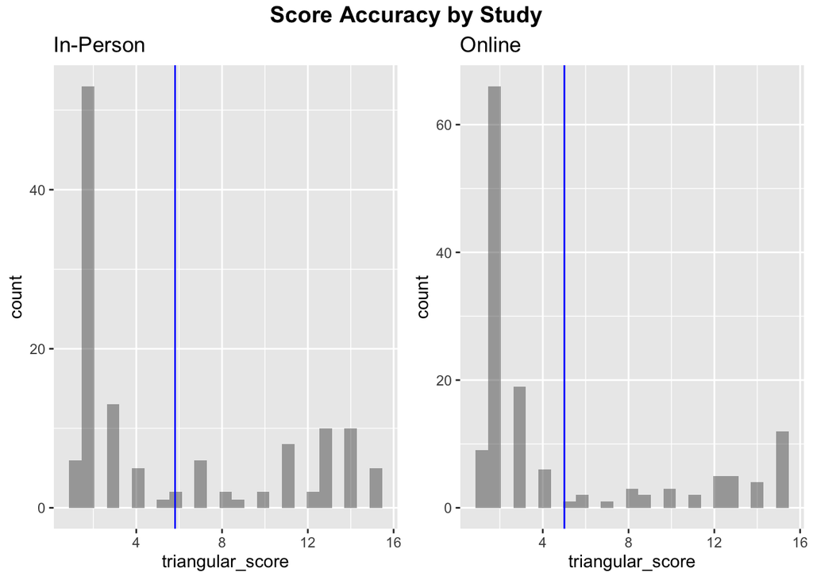

```r
#VISUALIZE distribution of response accuracy
plab <- gf_histogram(~triangular_score, data = df_lab) %>%
  gf_vline(xintercept = score.stats["lab",]$mean, color = "blue") +
  labs(title="In-Person")

ponline <- gf_histogram(~triangular_score, data = df_online) %>%
  gf_vline(xintercept = score.stats["online",]$mean, color = "blue") +
  labs(title="Online")

plot <-ggarrange(plab, ponline, common.legend = TRUE, nrow = 1, ncol =2)
annotate_figure(plot, top = text_grob("Score Accuracy by Study",
   color = "black", face = "bold", size = 14))
```

However, inspection of the quantile-quantile plots reveal that response accuracy does not approximate a normal distribution. After exploring several transformations and comparing against alternative distributions (log-normal, poisson, exp, nbinom), we conclude that we will need to use **robust tests** to analyze response accuracy.

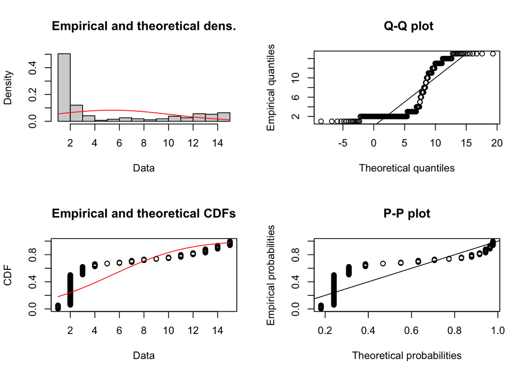

```r
plot(fitdist(df_subjects$triangular_score, "norm"))
```

```r
#EXPLORE ALTERNATIVES
# fit_n  <- fitdist(df_fall$triangular_score, "norm")
# fit_p  <- fitdist(df_fall$triangular_score, "pois")
# fit_b  <- fitdist(df_fall$triangular_score, "nbinom")

# par(mfrow=c(2,2))
# plot.legend <- c("normal", "poisson","nbinomial")
# denscomp(list(fit_n, fit_p, fit_b), legendtext = plot.legend)
# cdfcomp (list(fit_n, fit_p, fit_b), legendtext = plot.legend)
# qqcomp  (list(fit_n, fit_p, fit_b), legendtext = plot.legend)
# ppcomp  (list(fit_n, fit_p, fit_b), legendtext = plot.legend)
```

## Response Latency

```r
#DESCRIBE distribution of response time
time.stats <- rbind(
  "lab"= favstats(df_lab$tri_min),
  "online"= favstats(df_online$tri_min)
)
time.stats <- time.stats %>% dplyr::select(-missing) #don't need missing column
time.stats
```

```
##             min       Q1   median       Q3      max     mean       sd   n
## lab    3.770800 7.283617 8.804333 10.71089 19.98955 9.253020 2.902315 126
## online 1.983417 7.083704 8.811267 11.84312 27.87285 9.924459 4.527250 140
```

For *in person* response latency (for test block) (n = 126) range from 3.77 to 19.99 minutes, with a mean duration of (M = 9.25, SD = 2.9) minutes.

For *online replication* (online) response latency (for test block) (n = 140) range from 1.98 to 27.87 minutes, with a mean duration of (M = 9.92, SD = 4.53).

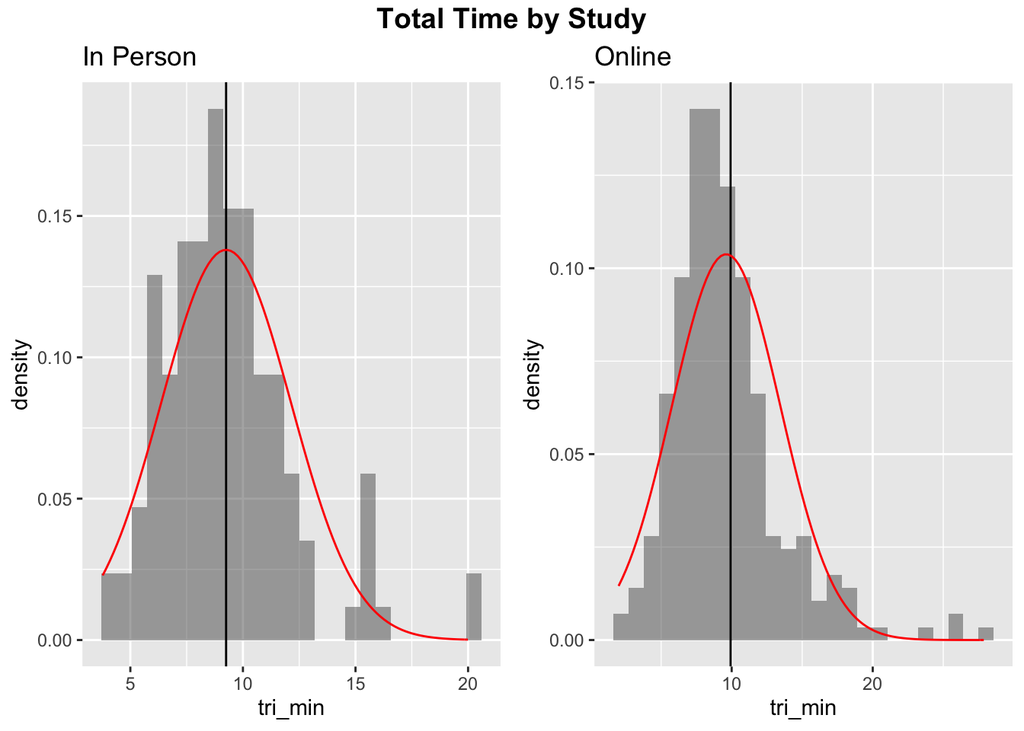

```r
#VISUALIZE distribution of response time
plab <- gf_dhistogram(~tri_min, data = df_lab) %>%
  gf_vline(xintercept = time.stats["lab",]$mean, color = "black") %>%
  gf_fitdistr(color="red")+
  labs(title="In Person")

ponline <- gf_dhistogram(~tri_min, data = df_subjects) %>%
  gf_vline(xintercept = time.stats["online",]$mean, color = "black") %>%
  gf_fitdistr(color="red")+
  labs(title="Online")

plot <-ggarrange(plab, ponline, common.legend = TRUE, nrow = 1, ncol =2)

annotate_figure(plot, top = text_grob("Total Time by Study",
   color = "black", face = "bold", size = 14))
```

The data may need to be log-transformed. But we will address this when modelling with the variable.

# HYPOTHESIS TESTING

## Response Accuracy by Condition

The experimental hypothesis (H1) is that structuring the data to pose an impasse (condition 121) will produce significantly better performance than non-impasse (condition 111). The null hypothesis (H0) is that there will be no difference in performance between conditions.

### [EXPLORE]

```r
#DESCRIBE scores by condition
score.cond.stats <- rbind(
  "lab" = favstats(triangular_score ~ condition, data = df_lab),
  "online" = favstats(triangular_score ~ condition, data = df_online)
)
score.cond.stats
```

```
##          condition min Q1 median    Q3 max     mean       sd  n missing
## lab.1          111   1  2    2.0  3.75  15 4.500000 4.643875 62       0
## lab.2          121   1  2    6.5 12.00  15 7.078125 4.828174 64       0
## online.1       111   1  2    2.0  3.00  15 3.897059 3.996789 68       0
## online.2       121   1  2    3.0 11.25  15 6.055556 5.156396 72       0
```

For **in person** study, participants in the impasse group had (on average) higher scores (M = 7.08 SD = 4.83) than those in the non-impasse control group (M = 4.5, SD = 4.64).

For **online replication** study, participants in the impasse group had (on average) higher scores (M = 6.06 SD = 5.16) than those in the non-impasse control group (M = 3.9, SD = 4).

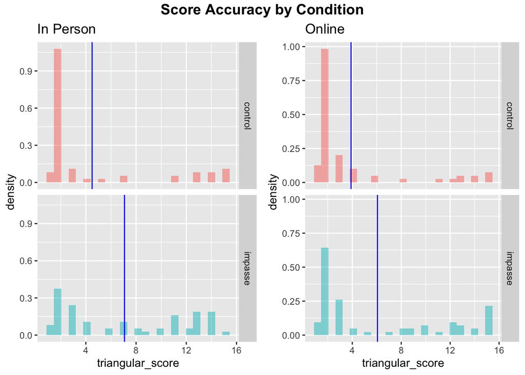

```r
#VISUALIZE scores by condition
condlables <- c("111"="control", "121"="impasse")
plab <- gf_dhistogram( ~triangular_score, fill= ~condition, data = df_lab) %>%
  gf_facet_grid(condition~., labeller=labeller(condition=condlables)) %>%
  gf_vline(xintercept = ~mean, data = score.cond.stats[c(1:2),], color = "blue")+
  labs(title="In Person")

ponline <- gf_dhistogram( ~triangular_score, fill= ~condition, data = df_online) %>%
  gf_facet_grid(condition~., labeller=labeller(condition=condlables)) %>%
  gf_vline(xintercept = ~mean, data = score.cond.stats[c(3:4),], color = "blue")+
  labs(title="Online")

plot <-ggarrange(plab, ponline, legend = FALSE, nrow = 1, ncol =2)
annotate_figure(plot, top = text_grob("Score Accuracy by Condition",
   color = "black", face = "bold", size = 14))
```

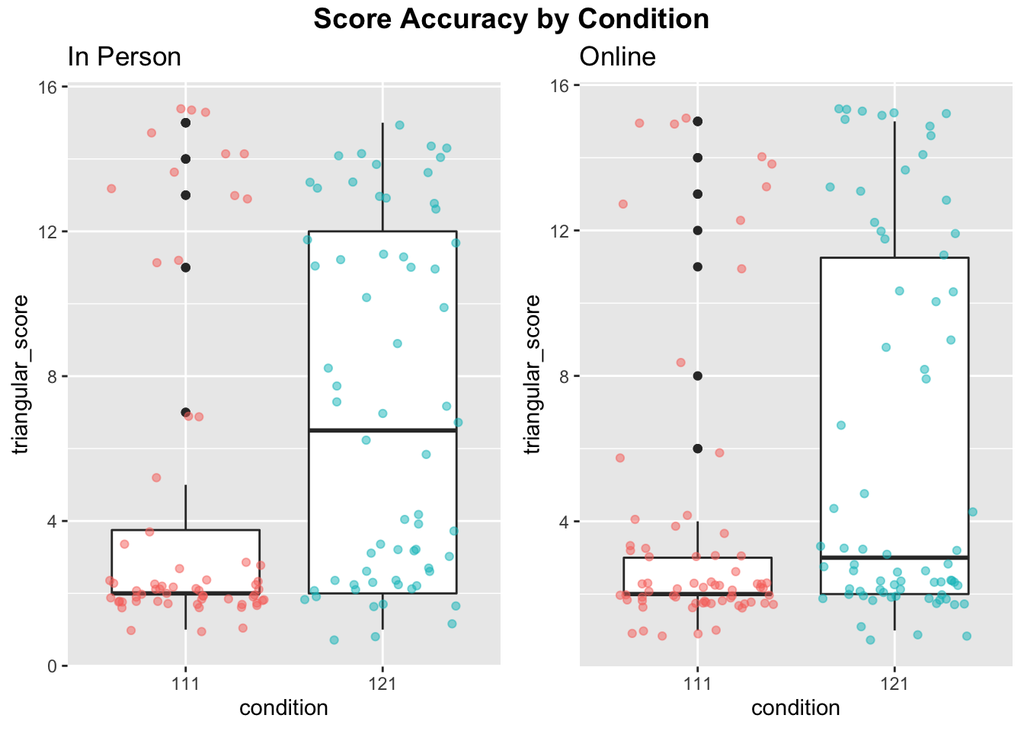

```r
#VISUALIZE scores by condition
plab <- gf_boxplot(triangular_score ~ condition, data=df_lab) %>%
  gf_jitter(color=~condition, alpha=0.5) +
  labs (title = "In Person")

ponline <- gf_boxplot(triangular_score ~ condition, data = df_online) %>%
  gf_jitter(color=~condition, alpha=0.5)+
  labs(title ="Online")

plot <-ggarrange(plab, ponline, legend = FALSE, nrow = 1, ncol =2)
annotate_figure(plot, top = text_grob("Score Accuracy by Condition",
   color = "black", face = "bold", size = 14))
```

### [MODEL]

Because the response accuracy data are not-normal, we will test the veracity of our hypothesis using Wilcoxon rank-sum test (Wilcoxon, 1945).

```r
#Wilcoxon Rank Sum Test
m1 <- wilcox.test(triangular_score ~ condition, data = df_lab, exact=FALSE,
                  alternative="less")
m1
```

```
##
##  Wilcoxon rank sum test with continuity correction
##
## data:  triangular_score by condition
## W = 1284.5, p-value = 0.0001922
## alternative hypothesis: true location shift is less than 0
```

```r
#Calculate Effect size
m1eff <- wilcox_effsize(triangular_score ~ condition, data = df_lab)
m1eff
```

```
## # A tibble: 1 × 7
##   .y.              group1 group2 effsize    n1    n2 magnitude
## * <chr>            <chr>  <chr>    <dbl> <int> <int> <ord>
## 1 triangular_score 111    121      0.317    62    64 moderate
```

**In Person** A one-tailed Wilcoxon rank-sum test reveals that the cummulative score (number of triangular-consistent responses)(Mdn = 6.5 points ) in the IMPASSE group were significantly higher than than scores in the non-impasse control condition (Mdn = 2), W = 1284.5 , p < 0.001, *r* = 0.3165359, a moderate-sized effect.

```r
#Wilcoxon Rank Sum Test
m1 <- wilcox.test(triangular_score ~ condition, data = df_online, exact=FALSE,
                  alternative="less")
m1
```

```
##
##  Wilcoxon rank sum test with continuity correction
##
## data:  triangular_score by condition
## W = 1848.5, p-value = 0.004087
## alternative hypothesis: true location shift is less than 0
```

```r
#Calculate Effect size
m1eff <- wilcox_effsize(triangular_score ~ condition, data = df_online)
m1eff
```

```
## # A tibble: 1 × 7
##   .y.              group1 group2 effsize    n1    n2 magnitude
## * <chr>            <chr>  <chr>    <dbl> <int> <int> <ord>
## 1 triangular_score 111    121      0.224    68    72 small
```

**Online** A one-tailed Wilcoxon rank-sum test reveals that the cummulative score (number of triangular-consistent responses)(Mdn = 3 points ) in the IMPASSE group were significantly higher than than scores in the non-impasse control condition (Mdn = 2), W = 1848.5 , p < 0.05, *r* = 0.2237108, a small effect.

**TODO:: Investigate outliers in online study; may need to have stricter response time + strategy-consistent response criteria**

### [REPLICATION]

```r
temp <- df_subjects %>% filter(condition==121)

#Wilcoxon Rank Sum Test
m1 <- wilcox.test(triangular_score ~ mode, data = temp, exact=FALSE,
                  alternative="greater")
m1
```

```
##
##  Wilcoxon rank sum test with continuity correction
##
## data:  triangular_score by mode
## W = 2620.5, p-value = 0.08069
## alternative hypothesis: true location shift is greater than 0
```

```r
#Calculate Effect size
m1eff <- wilcox_effsize(triangular_score ~ mode, data = temp)
m1eff
```

```
## # A tibble: 1 × 7
##   .y.              group1 group2 effsize    n1    n2 magnitude
## * <chr>            <chr>  <chr>    <dbl> <int> <int> <ord>
## 1 triangular_score lab    online   0.120    64    72 small
```

A one-tailed Wilcoxon rank-sum test reveals that the cummulative score (number of triangular-consistent responses)(Mdn = 6.5 points ) in the IN-PERSON (impasse condition) sample *were not* significantly higher than than scores in the REMOTE-ONLINE (impasse condition) sample (Mdn = 3), W = 2620.5 , p = 0.08 *r* = 0.1202775.

**Inference** Our replication study had comparable results to the in-person study, however the effect size was smaller, therefore we should consider increasing the sample size of future studies conducted online so as to ensure we have sufficient statistical power detect a smaller effect.

# DILLIGENCE

## Assumptions of Wilcoxon Rank-Sum

The Wilcoxon rank-sum test is the non-parametric alternative to a independent samples t-test and requires the following assumptions:  
1. The two samples are independent of one another <– MET by random sampling + assignment 2. The two populations have equal variance or spread <–TEST

```r
df_subjects %>% group_by(condition,mode) %>% summarize(var=var(triangular_score))
```

```
## # A tibble: 4 × 3
## # Groups:   condition [2]
##   condition mode     var
##   <fct>     <chr>  <dbl>
## 1 111       lab     21.6
## 2 111       online  16.0
## 3 121       lab     23.3
## 4 121       online  26.6
```

Variances between conditions in both Lab and Online samples are comparable